# ggbio_testing_karyotype

R. F. Pacheco

2024-04-26

```r
if (!require(BiocManager)) install.packages("BiocManager")  # Install BiocManager

# Define a function to install a package if it is not installed
installifnot <- function (pkg){
  if (!require(pkg, character.only=T)){
    BiocManager::install(pkg)
  }
}
# Install packages
if (!require(tydiverse)) installed.packages("tydiverse")
```

```
##      Package LibPath Version Priority Depends Imports LinkingTo Suggests
##      Enhances License License_is_FOSS License_restricts_use OS_type Archs
##      MD5sum NeedsCompilation Built
```

```r
if (!(require(ggplot2))) installed.packages("ggplot2")
if (!require(dplyr)) installed.packages("dplyr")

# BiocManager packages
installifnot("ggbio")
installifnot("Biostrings")
installifnot("GenomicRanges")
```

```r
require(ggbio)
require(ggplot2)
require(Biostrings)
require(GenomicRanges)
require(tydiverse)
require(dplyr)
```

# Load data

First we need to load the data that we will use to plot the karyotype. We will use the following data:

```r
# Load chromosome names and lengths:
Linf_chr_lengths <- read.csv("./L_infantum_seq_lengths.csv", sep=",", header=TRUE)

 # Load positive elements data:
positives_elements <- read.csv("./for_ggbio/1.positives_testing_elements.csv", sep=",", header=FALSE)

# Load negative elements data:
negative_elements <- read.csv("./for_ggbio/2.negatives_testing_elements.csv", sep=",", header=FALSE)

 # Load positive and negative elements with no difference markers:
pos_and_neg_NODIFF <- read.csv("./for_ggbio/3.pos_and_neg_NODIFF_testing_elements.csv", sep=",", header=FALSE)

# Load positive and negative elements with difference markers:
pos_and_neg_DIFF <- read.csv("./for_ggbio/4.pos_and_neg_DIFF_testing_elements.csv", sep=",", header=FALSE)

# Load LmSIDER2a elements:
LmSIDER2a <- read.csv("./for_ggbio/5.LmSIDER2a.csv", sep =",", header=FALSE)

# Load LmSIDER2b elements:
LmSIDER2b <- read.csv("./for_ggbio/6.LmSIDER2b.csv", sep=",", header=FALSE)

# LmSIDER2a and LmSIDER2b elements with DIFF:
LmSIDER2a_LmSIDER2b_NODIFF <- read.csv("./for_ggbio/7.LmSIDER2a_and_LmSIDER2b_NODIFF.csv", sep=",", header=FALSE)

# LmSIDER2a and LmSIDER2b elements with DIFF:
LmSIDER2a_LmSIDER2b_DIFF <- read.csv("./for_ggbio/8.LmSIDER2a_and_LmSIDER2b_DIFF.csv", sep=",", header=FALSE)

# All elements:
all_elements <- read.csv("./for_ggbio/9.pos_neg_LmSIDER2a_LmSIDER2b_DIFF.csv", sep=",", header=FALSE)
```

# Prepare and plot data

First we need to prepare the data to be plotted. We will use the `GenomicRanges` package to prepare the data. Then we will use the `ggbio` package to plot the data.

## Prepare `seqinfo` object

This file has the chromosome names and lengths. We will use this information to create a `seqinfo` object that will be used to plot the data.

```r
seq_info <- Seqinfo(
  seqnames = Linf_chr_lengths$seq_name,
  seqlengths = Linf_chr_lengths$seq_length,
  isCircular = rep(FALSE, nrow(Linf_chr_lengths)),
  genome = rep("Linf", nrow(Linf_chr_lengths))
  )
```

## All positive and negative elements

Here we’ll plot all the positives elements from the SIDER_RepetitiveSearcher software that passed the filter of being in more than 5 chromosomes and having a $evalue < 10^{-09}$. We’ll also plot the negative elements that passed the same filter.

### No difference markers

First, all the elements together without markers. The total number of elements is 3009.

```r
GR_pos_and_neg <- GRanges(
    seqnames = Rle(pos_and_neg_NODIFF$V1, rep(1, nrow(pos_and_neg_NODIFF))),
    ranges = IRanges(
        start = pos_and_neg_NODIFF$V2,
        end = pos_and_neg_NODIFF$V3
    ),
    strand = rep("*", nrow(pos_and_neg_NODIFF))
)

seqinfo(GR_pos_and_neg) <- seq_info
p1 <- GR_pos_and_neg
```

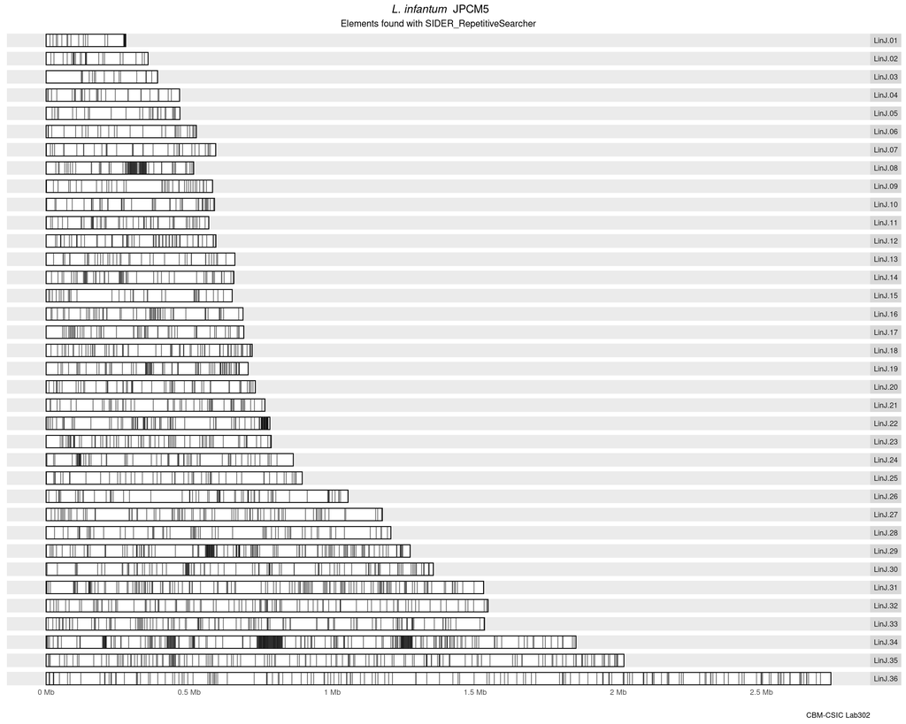

```r
autoplot(p1, layout = "karyogram", alpha=0.5) +
    labs(title = bquote(~ italic("L. infantum") ~ " JPCM5"),
         subtitle="Elements found with SIDER_RepetitiveSearcher",
         caption = "CBM-CSIC Lab302") +
    theme(plot.title = element_text(hjust=0.5),
          plot.subtitle = element_text(hjust=0.5))
```

### With difference markers

Here, the data will have an extra columns for some markers.

- Positive: 1951 elements.
- Negative: 1058 elements.

```r
GR_pos_and_neg_DIFF <- GRanges(
    seqnames = Rle(pos_and_neg_DIFF$V1, rep(1, nrow(pos_and_neg_DIFF))),
    ranges = IRanges(
        start = pos_and_neg_DIFF$V2,
        end = pos_and_neg_DIFF$V3
    ),
    strand = rep("*", nrow(pos_and_neg_DIFF))
)

seqinfo(GR_pos_and_neg_DIFF) <- seq_info

mcols(GR_pos_and_neg_DIFF) <- DataFrame(DIFF = pos_and_neg_DIFF$V5)
p2 <- GR_pos_and_neg_DIFF
```

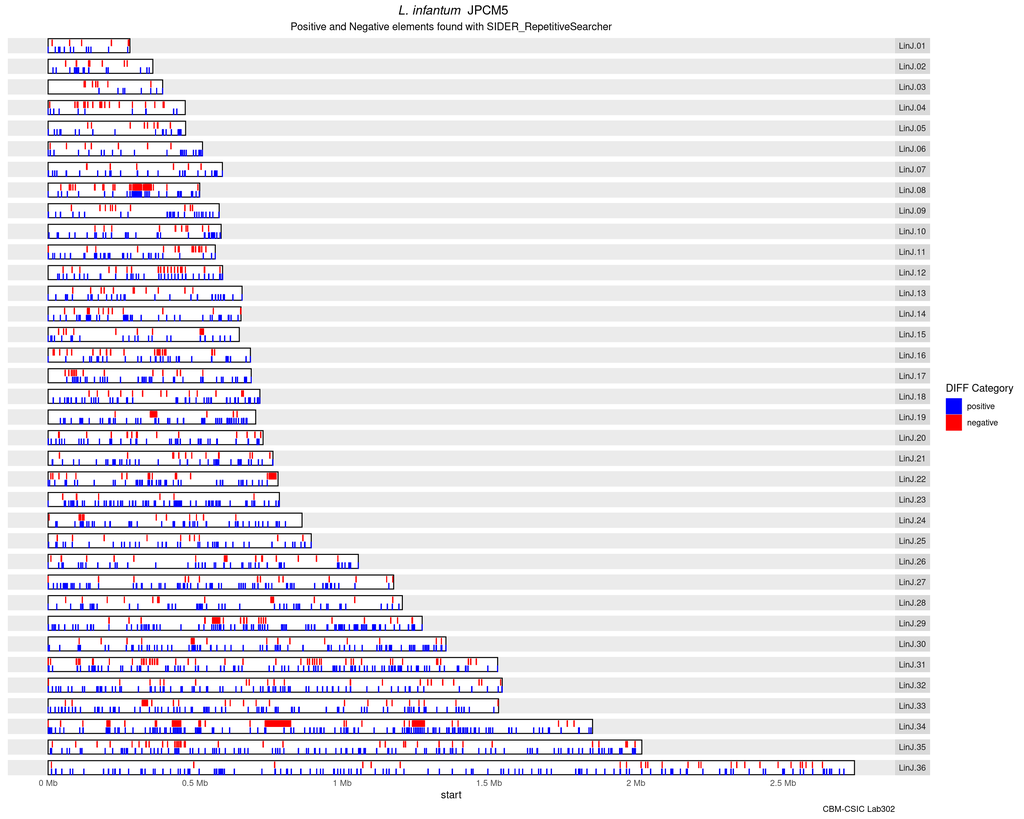

```r
autoplot(seqinfo(p2[p2$DIFF == "positive"]), layout="karyogram") +
    layout_karyogram(p2[p2$DIFF == "positive"], geom="rect", ylim = c(0, 4),
                     aes(color = "positive", fill="positive")) +
    layout_karyogram(p2[p2$DIFF == "negative"], geom="rect", ylim = c(5, 9),
                     aes(color = "negative", fill="negative")) +
    scale_color_manual(name = "DIFF Category",
                       values = c("positive" = "blue", "negative" = "red"),
                       breaks = c("positive", "negative")) +
    scale_fill_manual(name = "DIFF Category",
                      values = c("positive" = "blue", "negative" = "red"),
                      breaks=c("positive", "negative")) +
    labs(title = bquote(~ italic("L. infantum") ~ " JPCM5"),
         subtitle="Positive and Negative elements found with SIDER_RepetitiveSearcher",
         caption = "CBM-CSIC Lab302") +
    theme(plot.title = element_text(hjust=0.5),
          plot.subtitle = element_text(hjust=0.5))
```

### Only positives

Now, well do the same but with only the 1951 positive elements.

```r
GR_positives <- GRanges(
    seqnames = Rle(positives_elements$V1, rep(1, nrow(positives_elements))),
    ranges = IRanges(
        start = positives_elements$V2,
        end = positives_elements$V3
    ),
    strand = rep("*", nrow(positives_elements))
)

seqinfo(GR_positives) <- seq_info
p3 <- GR_positives
```

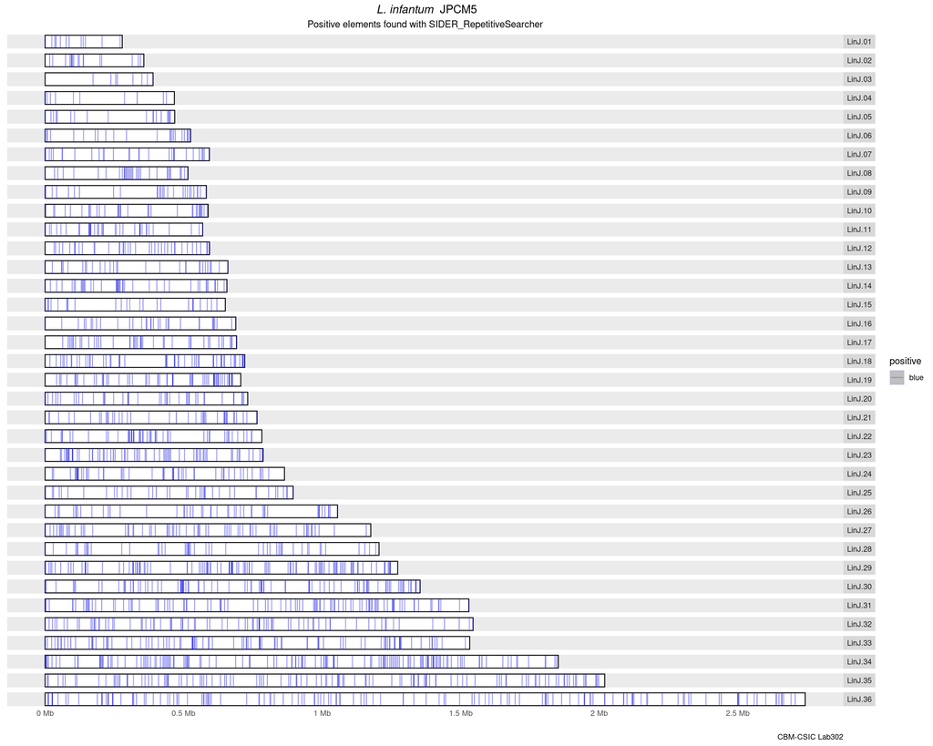

```r
autoplot(p3, layout = "karyogram", alpha=0.3, aes(color="blue")) +
    scale_color_manual(values = alpha(c("blue"),0.1), name="positive") +
    labs(title = bquote(~ italic("L. infantum") ~ " JPCM5"),
         subtitle="Positive elements found with SIDER_RepetitiveSearcher",
         caption = "CBM-CSIC Lab302") +
    theme(plot.title = element_text(hjust=0.5),
          plot.subtitle = element_text(hjust=0.5))
```

### Only negatives

And for the 1058 negatives elements.

```r
GR_negatives <- GRanges(
    seqnames = Rle(negative_elements$V1, rep(1, nrow(negative_elements))),
    ranges = IRanges(
        start = negative_elements$V2,
        end = negative_elements$V3
    ),
    strand = rep("*", nrow(negative_elements))
)

seqinfo(GR_negatives) <- seq_info
p4 <- GR_negatives
```

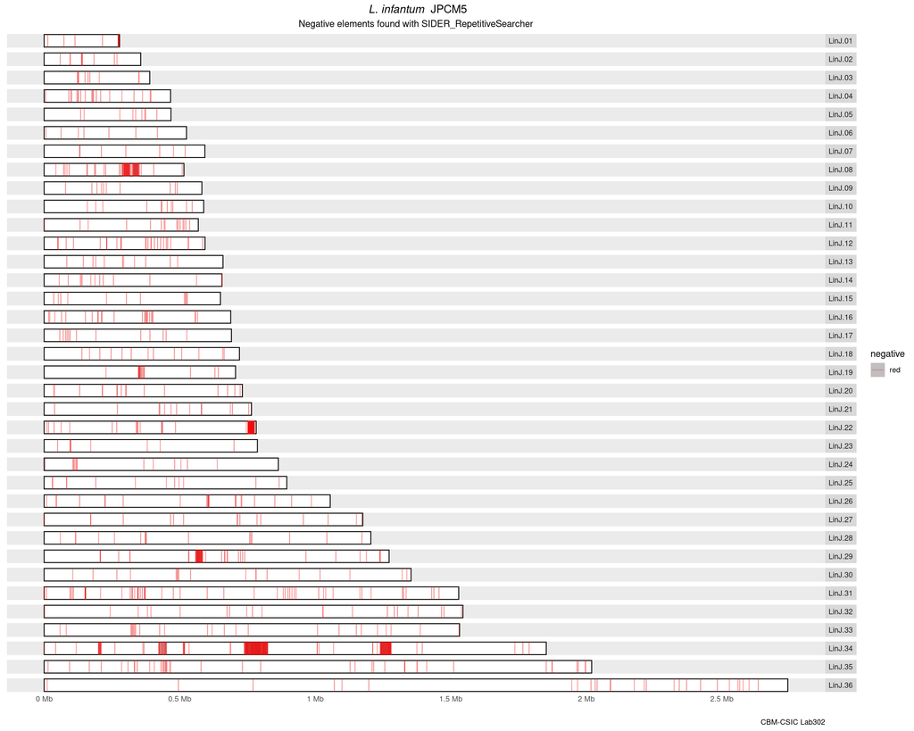

```r
autoplot(p4, layout = "karyogram", alpha=0.3, aes(color="red")) +
    scale_color_manual(values = alpha(c("red"),0.1), name="negative") +
    labs(title = bquote(~ italic("L. infantum") ~ " JPCM5"),
         subtitle="Negative elements found with SIDER_RepetitiveSearcher",
         caption = "CBM-CSIC Lab302") +
    theme(plot.title = element_text(hjust=0.5),
          plot.subtitle = element_text(hjust=0.5))
```

## LmSIDER2a and LmSIDER2b elements

### LmSIDER2a and LmSIDER2b elements with difference

Now for the “new” elements not found using my program:

- LmSIDER2a: 40 elements.
- LmSIDER2b: 10 elements.

```r
GR_LmSIDER2a_LmSIDER2b_DIFF <- GRanges(
    seqnames = Rle(LmSIDER2a_LmSIDER2b_DIFF$V1, rep(1, nrow(LmSIDER2a_LmSIDER2b_DIFF))),
    ranges = IRanges(
        start = LmSIDER2a_LmSIDER2b_DIFF$V2,
        end = LmSIDER2a_LmSIDER2b_DIFF$V3
    ),
    strand = rep("*", nrow(LmSIDER2a_LmSIDER2b_DIFF))
)
```

```r
common_seqlevels <- intersect(seqlevels(GR_LmSIDER2a_LmSIDER2b_DIFF), seqlevels(seq_info))
GR_LmSIDER2a_LmSIDER2b_DIFF <- keepSeqlevels(GR_LmSIDER2a_LmSIDER2b_DIFF, common_seqlevels, pruning.mode = "coarse")
seq_info2 <- seq_info[seqlevels(GR_LmSIDER2a_LmSIDER2b_DIFF)]
seqnames_ordered <- seqnames(seq_info2)[order(as.numeric(sub("LinJ.", "", seqnames(seq_info2))))]
seq_info2_ordered <- seq_info2[seqnames_ordered]

seqlevels(GR_LmSIDER2a_LmSIDER2b_DIFF) <- seqlevels(seq_info2_ordered)
seqinfo(GR_LmSIDER2a_LmSIDER2b_DIFF) <- seq_info2_ordered

mcols(GR_LmSIDER2a_LmSIDER2b_DIFF) <- DataFrame(DIFF = LmSIDER2a_LmSIDER2b_DIFF$V5)

p5 <- GR_LmSIDER2a_LmSIDER2b_DIFF
```

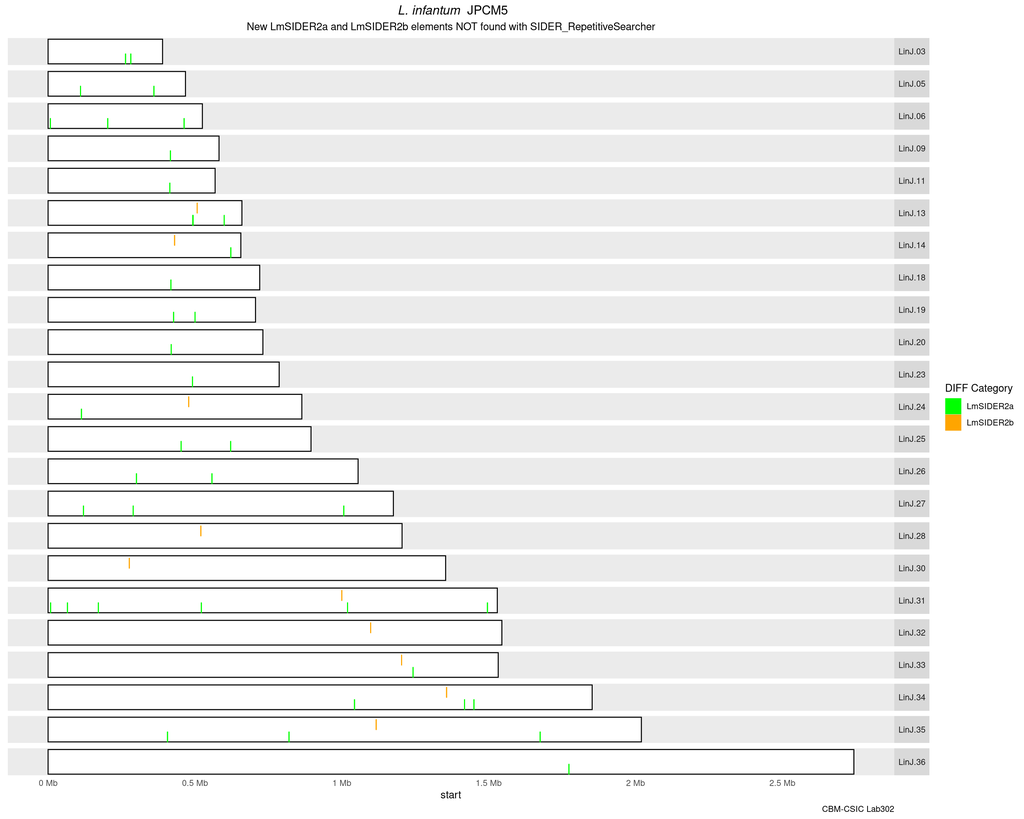

```r
autoplot(seqinfo(p5[p5$DIFF == "LmSIDER2a"]), layout="karyogram") +
    layout_karyogram(p5[p5$DIFF == "LmSIDER2a"], geom="rect", ylim = c(0, 4),
                     aes(color = "LmSIDER2a", fill="LmSIDER2a")) +
    layout_karyogram(p5[p5$DIFF == "LmSIDER2b"], geom="rect", ylim = c(5, 9),
                     aes(color = "LmSIDER2b", fill="LmSIDER2b")) +
    scale_color_manual(name = "DIFF Category",
                       values = c("LmSIDER2a" = "green", "LmSIDER2b" = "orange"),
                       breaks = c("LmSIDER2a", "LmSIDER2b")) +
    scale_fill_manual(name = "DIFF Category",
                      values = c("LmSIDER2a" = "green", "LmSIDER2b" = "orange"),
                      breaks=c("LmSIDER2a", "LmSIDER2b")) +
    labs(title = bquote(~ italic("L. infantum") ~ " JPCM5"),
         subtitle="New LmSIDER2a and LmSIDER2b elements NOT found with SIDER_RepetitiveSearcher",
         caption = "CBM-CSIC Lab302") +
    theme(plot.title = element_text(hjust=0.5),
          plot.subtitle = element_text(hjust=0.5))
```

### LmSIDER2 and positive elements

```r
GR_LmSIDER_and_pos <- GRanges(
    seqnames = Rle(all_elements$V1, rep(1, nrow(all_elements))),
    ranges = IRanges(
        start = all_elements$V2,
        end = all_elements$V3
    ),
    strand = rep("*", nrow(all_elements))
)

seqinfo(GR_LmSIDER_and_pos) <- seq_info

mcols(GR_LmSIDER_and_pos) <- DataFrame(DIFF = all_elements$V5)

p6 <- GR_LmSIDER_and_pos
```

```r
autoplot(seqinfo(p6[p6$DIFF == "positive"]), layout="karyogram") +
    layout_karyogram(p6[p6$DIFF == "positive"], geom="rect", ylim = c(0, 2),
                     aes(color = "positive", fill="positive")) +
    layout_karyogram(p6[p6$DIFF == "LmSIDER2a"], geom="rect", ylim = c(3, 6),
                     aes(color = "LmSIDER2a", fill="LmSIDER2a")) +
    layout_karyogram(p6[p6$DIFF == "LmSIDER2b"], geom="rect", ylim = c(7, 9),
                     aes(color = "LmSIDER2b", fill="LmSIDER2b")) +
    scale_color_manual(name = "DIFF Category",
                       values = c("positive" = "blue", "LmSIDER2a" = "green", "LmSIDER2b" = "orange"),
                       breaks = c("positive", "LmSIDER2a", "LmSIDER2b")) +
    scale_fill_manual(name = "DIFF Category",
                      values = c("positive" = "blue", "LmSIDER2a" = "green", "LmSIDER2b" = "orange"),
                      breaks=c("positive", "LmSIDER2a", "LmSIDER2b")) +
    labs(title = bquote(~ italic("L. infantum") ~ " JPCM5"),
         subtitle="New LmSIDER2a, LmSIDER2b and Positive elemetns",
         caption = "CBM-CSIC Lab302") +
    theme(plot.title = element_text(hjust=0.5),
          plot.subtitle = element_text(hjust=0.5))
```

[figure not shown]